# Credit Card Users Churn Prediction

#### Distribution of numerical feature against the target varaible

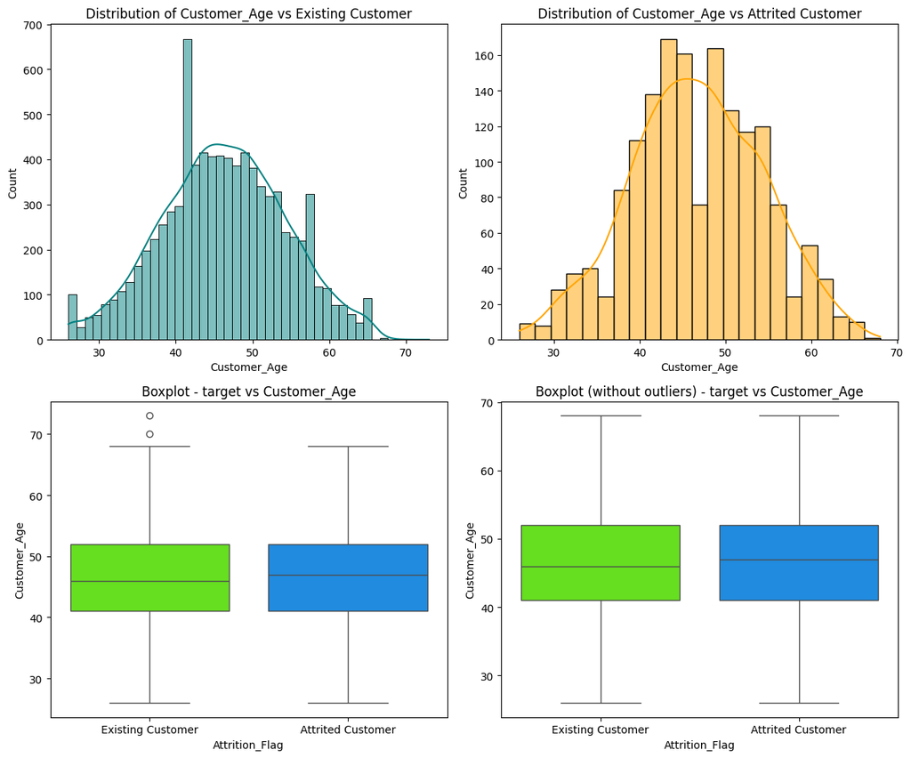

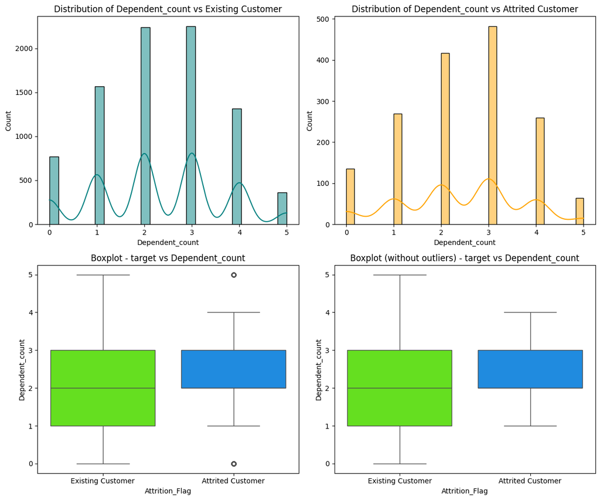

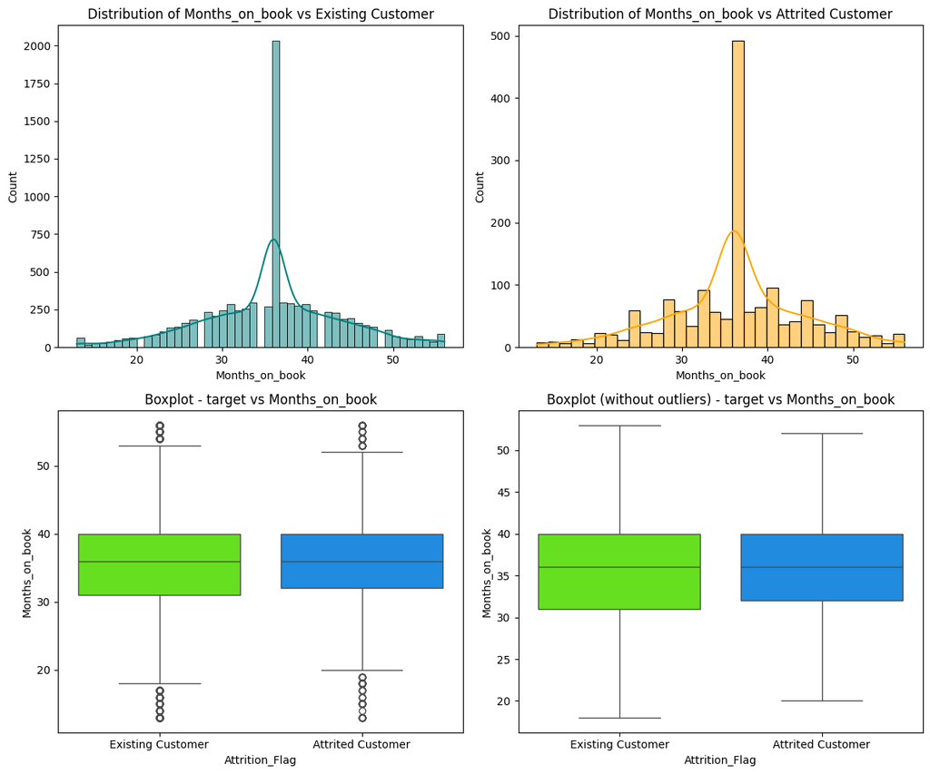

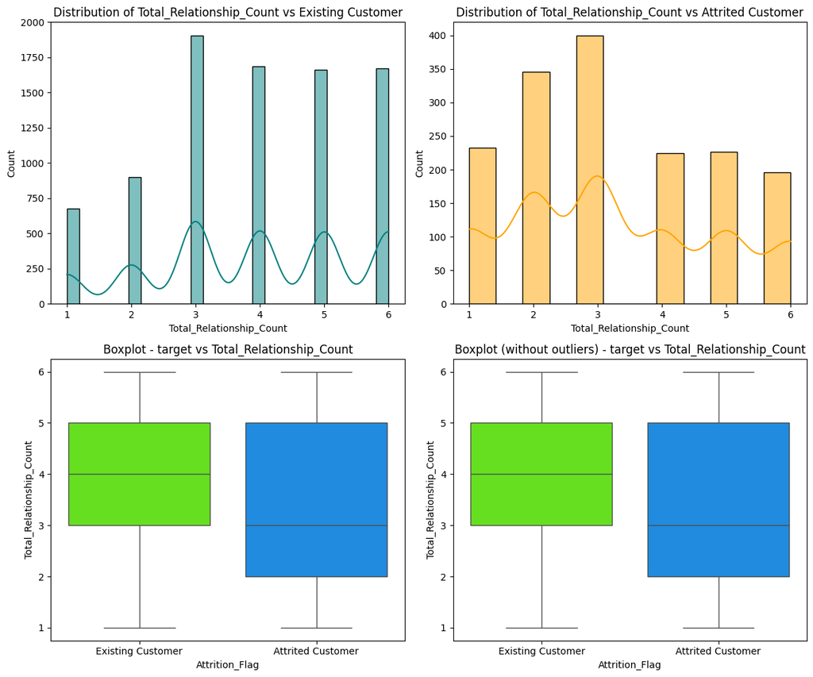

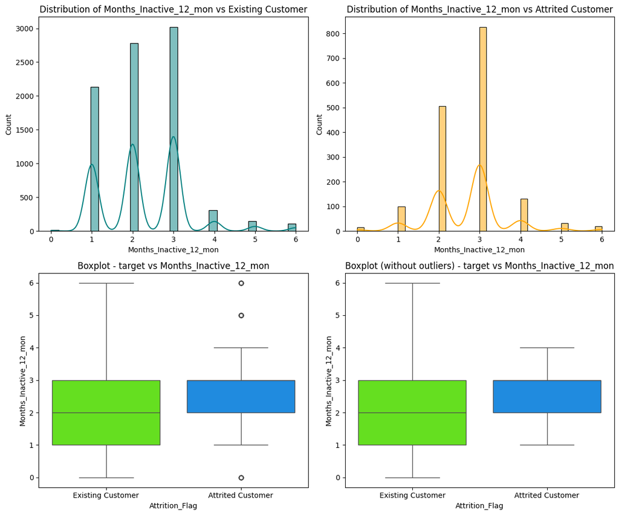

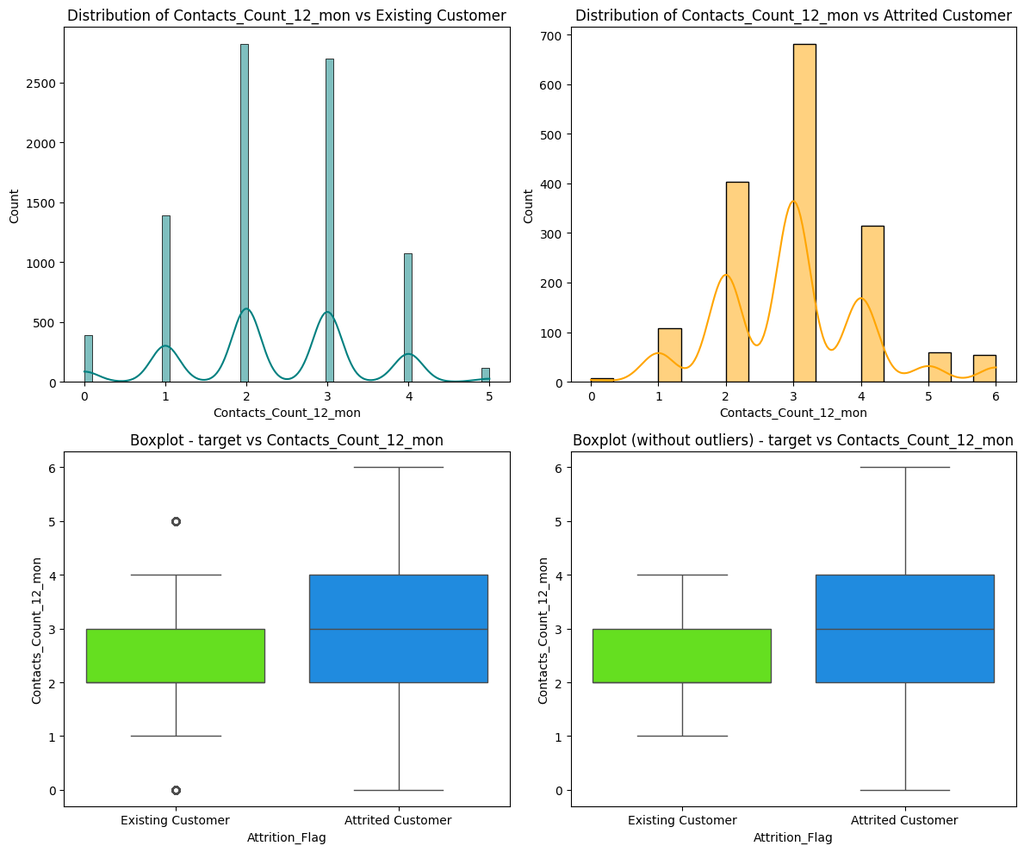

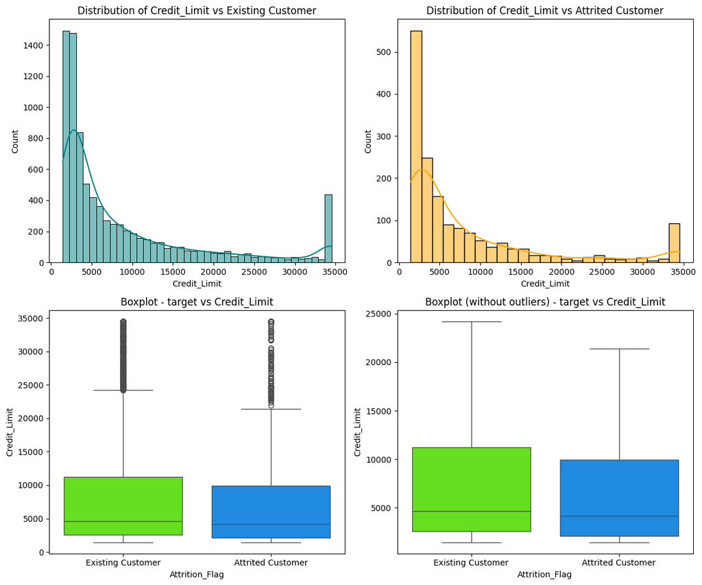

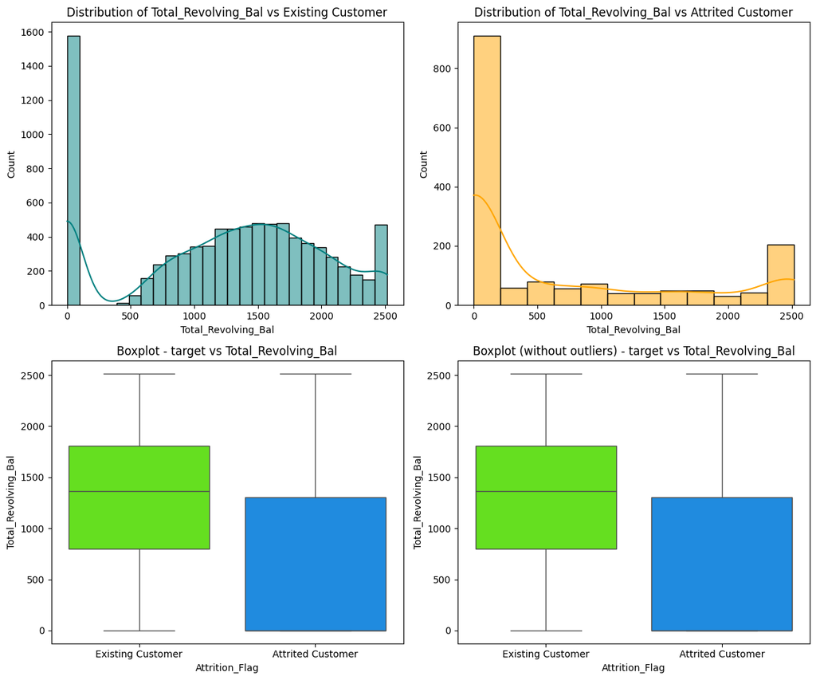

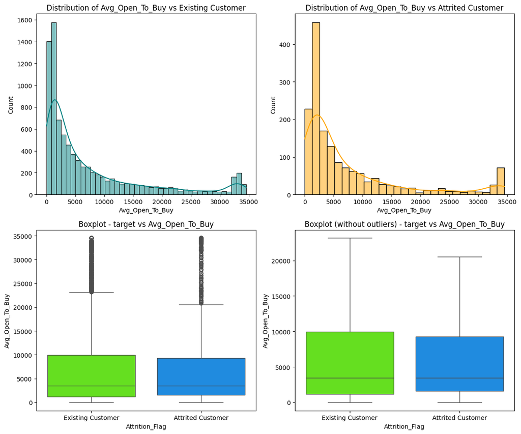

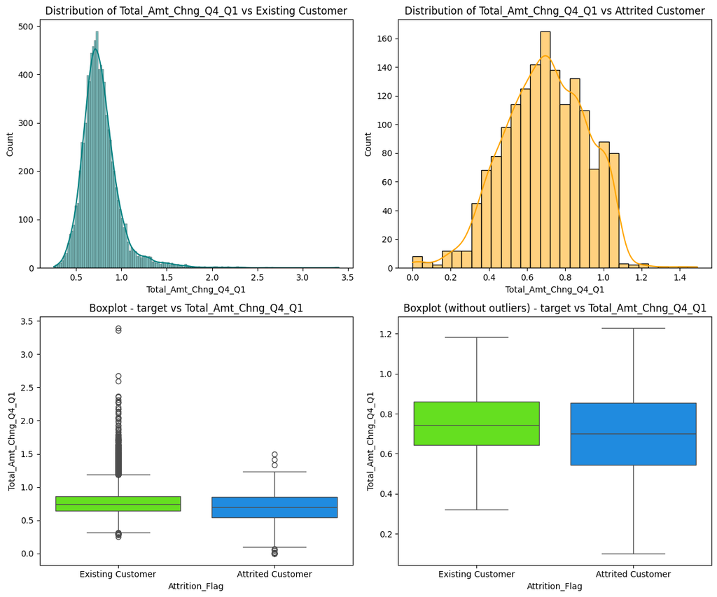

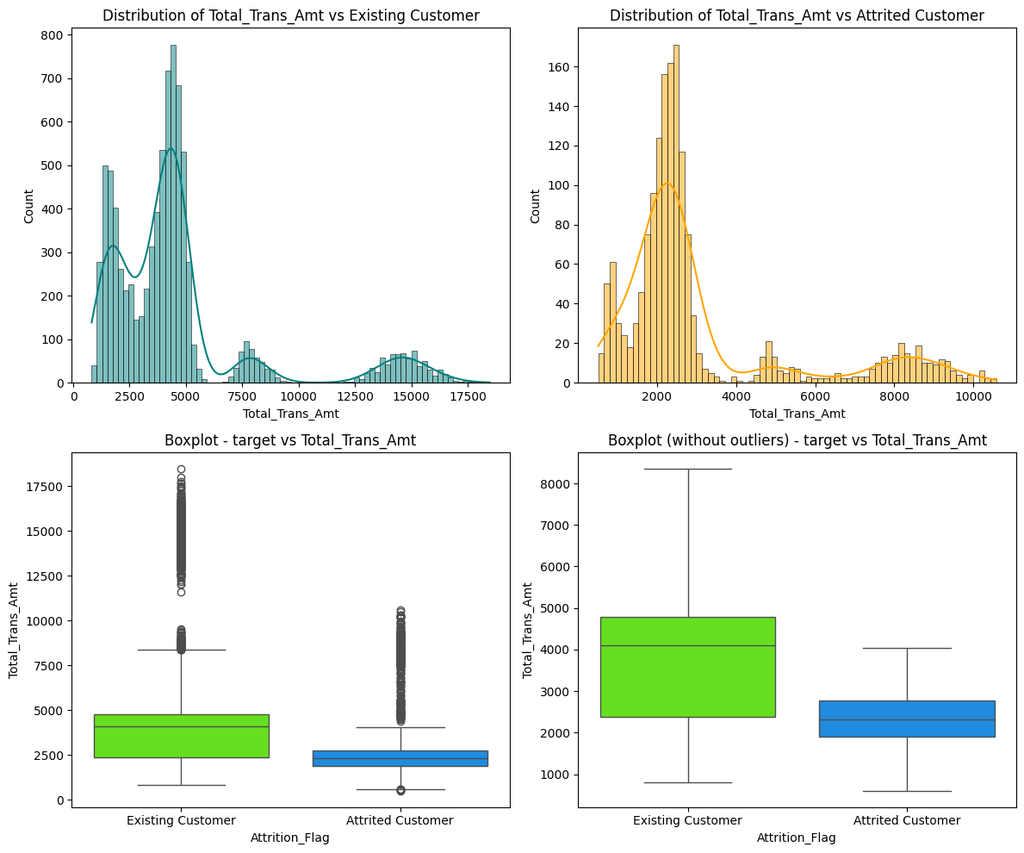

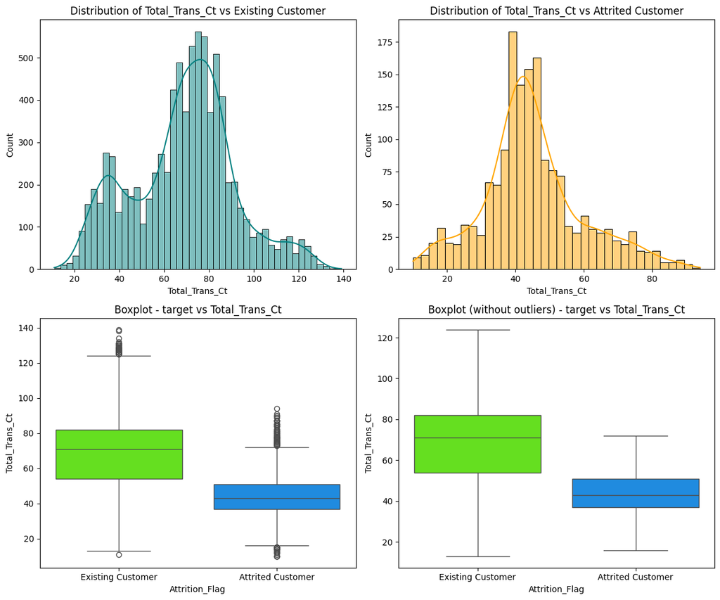

[2 more figures not shown]

```python
for col in num_cols:
  distribution_plot_wrt_target(data, col, target)
```

```python
print('Attrited customer age 25th percentile:', data.loc[data['Attrition_Flag'] == "Attrited Customer", 'Customer_Age'].quantile(0.25))
print('25th percentile relationship duration with the bank for attrited customer:', data.loc[data['Attrition_Flag'] == "Attrited Customer", 'Months_on_book'].quantile(0.25))
print('25th percentile relationship duration with the bank existing customer:',data.loc[data['Attrition_Flag'] == "Existing Customer", 'Months_on_book'].quantile(0.25))
print('75th percntile credit limit for attrited customer:',data.loc[data['Attrition_Flag'] == "Attrited Customer", 'Credit_Limit'].quantile(0.75))
print('75th percentile revolving balance for attrited customer:',data.loc[data['Attrition_Flag'] == "Attrited Customer", 'Total_Revolving_Bal'].quantile(0.75))
print('75th percentile revolving balance for existing customer:',data.loc[data['Attrition_Flag'] == "Existing Customer", 'Total_Revolving_Bal'].quantile(0.75))
print('25th percentile revolving balance for attrited customer:',data.loc[data['Attrition_Flag'] == "Attrited Customer", 'Total_Revolving_Bal'].quantile(0.25))
print('75th percentile amount left in credit card to use for attrited customer',data.loc[data['Attrition_Flag'] == "Attrited Customer", 'Avg_Open_To_Buy'].quantile(0.75))
print('75th percentile amount left in credit card to use for existing customer',data.loc[data['Attrition_Flag'] == "Existing Customer", 'Avg_Open_To_Buy'].quantile(0.75))
print('75th percentile transaction Amount Change for existing customer:',data.loc[data['Attrition_Flag'] == "Existing Customer", 'Total_Amt_Chng_Q4_Q1'].quantile(0.75))
print('75th percentile transaction Amount Change for attrited customer:', data.loc[data['Attrition_Flag'] == "Attrited Customer", 'Total_Amt_Chng_Q4_Q1'].quantile(0.75))
print('75th percentile Total Transaction Amount for attrited customer:',data.loc[data['Attrition_Flag'] == "Attrited Customer", 'Total_Trans_Amt'].quantile(0.75))
print('75th percentile Total Transaction Amount for existing customer',data.loc[data['Attrition_Flag'] == "Existing Customer", 'Total_Trans_Amt'].quantile(0.75))
print('75th percentile Total Transaction Count for attrited customer:',data.loc[data['Attrition_Flag'] == "Attrited Customer", 'Total_Trans_Ct'].quantile(0.75))
print('25th percentile Total Transaction Count for existing customer:',data.loc[data['Attrition_Flag'] == "Existing Customer", 'Total_Trans_Ct'].quantile(0.25))
```

```
Attrited customer age 25th percentile: 41.0
25th percentile relationship duration with the bank for attrited customer: 32.0
25th percentile relationship duration with the bank existing customer: 31.0
75th percntile credit limit for attrited customer: 9933.5
75th percentile revolving balance for attrited customer: 1303.5
75th percentile revolving balance for existing customer: 1807.0
25th percentile revolving balance for attrited customer: 0.0
75th percentile amount left in credit card to use for attrited customer 9257.5
75th percentile amount left in credit card to use for existing customer 9978.25
75th percentile transaction Amount Change for existing customer: 0.86
75th percentile transaction Amount Change for attrited customer: 0.856
75th percentile Total Transaction Amount for attrited customer: 2772.0
75th percentile Total Transaction Amount for existing customer 4781.25
75th percentile Total Transaction Count for attrited customer: 51.0
25th percentile Total Transaction Count for existing customer: 54.0
```

```python
print('Number of attrited customers who were inactive over 4 months(outliers)',(data.loc[data['Attrition_Flag'] == "Attrited Customer", 'Months_Inactive_12_mon'] > 4).sum())
print('Number of attrited customers who were never inactive (outliers)',(data.loc[data['Attrition_Flag'] == "Attrited Customer", 'Months_Inactive_12_mon'] == 0).sum())
```

```
Number of attrited customers who were inactive over 4 months(outliers) 51
Number of attrited customers who were never inactive (outliers) 15
```

```python
existing_cust_75th_perc = data.loc[data['Attrition_Flag'] == "Existing Customer", 'Total_Ct_Chng_Q4_Q1'].quantile(0.75)
existing_cust_reduce_spending = (1 - existing_cust_75th_perc)*100
print(f'75th percentile q4 and q1 transaction count ratio for existing customer: {existing_cust_75th_perc}')
print(f'75th percentile spending change for existing customer in q4: {existing_cust_reduce_spending:.2f}%')
attr_cust_75th_perc = data.loc[data['Attrition_Flag'] == "Attrited Customer", 'Total_Ct_Chng_Q4_Q1'].quantile(0.75)
attr_cust_reduce_spending = (1 - attr_cust_75th_perc)*100
print(f'75th percentile q4 and q1 transaction count ratio for attrited customer: {attr_cust_75th_perc}')
print(f'75th percentile spending change for attrited customer in q4: {attr_cust_reduce_spending:.2f}%')
```

```
75th percentile q4 and q1 transaction count ratio for existing customer: 0.833
75th percentile spending change for existing customer in q4: 16.70%
75th percentile q4 and q1 transaction count ratio for attrited customer: 0.692
75th percentile spending change for attrited customer in q4: 30.80%
```

```python
print('75th percentile avg. utilization ratio for existing customer:', data.loc[data['Attrition_Flag'] == "Existing Customer", 'Avg_Utilization_Ratio'].quantile(0.75))
print('75th percentile avg. utilization ratio for attrited customer:', data.loc[data['Attrition_Flag'] == "Attrited Customer", 'Avg_Utilization_Ratio'].quantile(0.75))
```

```
75th percentile avg. utilization ratio for existing customer: 0.52925
75th percentile avg. utilization ratio for attrited customer: 0.231
```

#### Correlation Analysis (Numerical data)

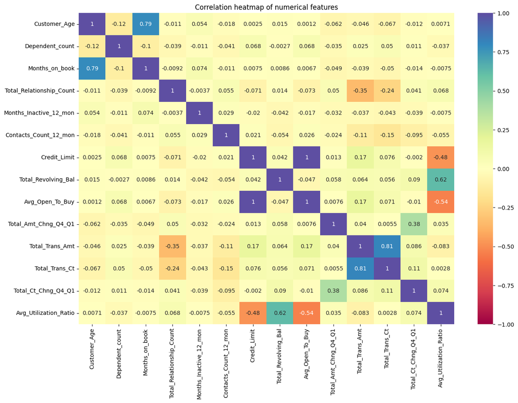

```python
plt.figure(figsize=(15,10))
sns.heatmap(data.corr(numeric_only=True), annot=True, vmax=1, vmin = -1, cmap='Spectral')
plt.title("Correlation heatmap of numerical features")
plt.show()
```

#### Correlation Analysis (Chi-squared test for categorical data)

```python
def chi_square_test(data, predictor, target):
  crosstab = pd.crosstab(data[predictor], data[target])
  Ho = f"{predictor} has no effect on {target}"  # Stating the Null Hypothesis
  Ha = f"{predictor} has an effect on {target}"  # Stating the Alternate Hypothesis

  chi, p_value, dof, expected = stats.chi2_contingency(crosstab)

  if p_value < 0.05:  # Setting our significance level at 5%
      print(f"{Ha} as the p_value ({p_value.round(3)}) < 0.05")
  else:
      print(f"{Ho} as the p_value ({p_value.round(3)}) > 0.05")
```

```python
for col in cat_cols:
  chi_square_test(data, col, target)
```

```
Gender has an effect on Attrition_Flag as the p_value (0.0) < 0.05
Education_Level has no effect on Attrition_Flag as the p_value (0.051) > 0.05
Marital_Status has no effect on Attrition_Flag as the p_value (0.109) > 0.05
Income_Category has an effect on Attrition_Flag as the p_value (0.025) < 0.05
Card_Category has no effect on Attrition_Flag as the p_value (0.525) > 0.05
```

#### Observations

- More female customers attrited than male customers. Female customers are 52.9% of total number of customers. The attrition rate is also higher among female customers, 57.1% of total attrited customers. Attrition rate among female customers around 17.3%, but, attrition rate among male customers is around 14.6%.
- Among all attrited customers 29.9% have graduate level education. The attrition rate is the highest, around 21%, among Doctorate level educated customers followed by post-graduate level educated customers.
- Attrition rate among married, single, divorced and unknow marital status customers are almost similar around 16% to 17%
- Attrition rate of high earning customers and relatively low earning customers are very similar. Attrition rate is the highest, around 17.3%, among customers who earn over 120k. Customers who earn less than 40k has also attrition rate of 17.1%. It is important to note that around 35% of all customers are earning less than 40k, while only 7% customers are earning more than 120k. Attrition rate is the lowest, 13.4%, among customers who earn between 60k to 80k. Only around 13.8% customers earn between 60k to 80k.
- Platinum and Gold customers have the highest attrition rate 25% and 18% respectively though these customer only represent a small proportion of total customers around 0.2% and 1% respectively.
- 75% customers who attrited are of 41 years age or over
- 75% customers who didn't attrite have at least 1 dependent but 75% customers who attrited have at least 2 dependents.
- 75% customers who attrited have relationship with bank 32 months or more, where as, 75% customers who didn't attrite have months on book 31 months or more
- 75% customers who attrited have at least 2 products with the bank, where as, 75% customers who stayed have at least 3 products with the bank.
- 75% customers who attrited were inactive at least 2 months or more in the last 12 month, where as, the customers who stayed were inactive at least 1 month or more. There are some outliers for attrited customers. 51 attrited customers were inactive more than 4 months. There are 15 attrited customers who were not inactive over the 12 months.
- 75% customers who attrited made 2 to 6 contacts, where as 75% customers who stayed made 2 to 4 contacts(excluding outliers).
- 75% customers who attrited have credit limit less than \$10k.
- Customers who attrited have lower revolving balance than those of who stayed. 25% attrited customers have 0 revolving balance.
- `Avg_Open_To_Buy` has almost similar distribution aginst customer who attrited and customer who stayed, though the 75th percentile for customers who stayed is slightly higher than those of who attrited.
- 75% customers in both group spent less in Q4 than Q1. In both cases the spending is at least around 14% less.
- 75% customers who attrited have transaction amount around \$2,772 or less where as 75% customers who stayed have transaction amount around \$4781 or less.
- 75% attrited customers have total transaction count 51 or less, where as, 75% existing customers have at least 54 transaction in last 12 month.
- 75% existing customers reducing the number of transactions at least by 16.7% in Q4 compared to Q1, where as, 75% attrited customer reducing the number of transactions at least by 30.8% in Q4 compared to Q1.
- 75% existing customers have utlization ratio 52.9% or less where as 75% attrited customers have utilization ratio 23.1% or less.
- `Months_on_book` has strong positive correlation with `Customer_Age`. `Credit_Limit` has strogest postive correlation of 1 with `Avg_Open_To_Buy`. `Total_Trans_Amt` has strong postive correlation with `Total_Trans_CT`. `Avg_Utilization_Ratio` has moderate postive correlation with `Total_Revolving_Bal`.

`Credit_Limit` has moderate negative correlation with `Avg_Utilization_Ratio`. `Avg_Open_To_Buy` has moderate negative correlation with `Avg_Utilization_Ratio`

- From the Chi-squared test we observed that `Gender` and `Income_category` has an effect on our target variable `Attrition_Flag`

## Data Pre-processing

### Changing object data type to category and mapping of the target variable

```python
# converts object type to category
for col in data.select_dtypes(include='object').columns.to_list():
  data[col] = data[col].astype('category')
data.head()
```

|  | Attrition_Flag | Customer_Age | Gender | Dependent_count | Education_Level | Marital_Status | Income_Category | Card_Category | Months_on_book | Total_Relationship_Count | Months_Inactive_12_mon | Contacts_Count_12_mon | Credit_Limit | Total_Revolving_Bal | Avg_Open_To_Buy | Total_Amt_Chng_Q4_Q1 | Total_Trans_Amt | Total_Trans_Ct | Total_Ct_Chng_Q4_Q1 | Avg_Utilization_Ratio |
| --- | --- | --- | --- | --- | --- | --- | --- | --- | --- | --- | --- | --- | --- | --- | --- | --- | --- | --- | --- | --- |
| 0 | Existing Customer | 45 | M | 3 | High School | Married | $60K - $80K | Blue | 39 | 5 | 1 | 3 | 12691.0 | 777 | 11914.0 | 1.335 | 1144 | 42 | 1.625 | 0.061 |
| 1 | Existing Customer | 49 | F | 5 | Graduate | Single | Less than $40K | Blue | 44 | 6 | 1 | 2 | 8256.0 | 864 | 7392.0 | 1.541 | 1291 | 33 | 3.714 | 0.105 |
| 2 | Existing Customer | 51 | M | 3 | Graduate | Married | $80K - $120K | Blue | 36 | 4 | 1 | 0 | 3418.0 | 0 | 3418.0 | 2.594 | 1887 | 20 | 2.333 | 0.000 |
| 3 | Existing Customer | 40 | F | 4 | High School | Unknown | Less than $40K | Blue | 34 | 3 | 4 | 1 | 3313.0 | 2517 | 796.0 | 1.405 | 1171 | 20 | 2.333 | 0.760 |
| 4 | Existing Customer | 40 | M | 3 | Uneducated | Married | $60K - $80K | Blue | 21 | 5 | 1 | 0 | 4716.0 | 0 | 4716.0 | 2.175 | 816 | 28 | 2.500 | 0.000 |

```python
data['Attrition_Flag'] = data['Attrition_Flag'].map({'Existing Customer': 0, 'Attrited Customer': 1})
```

```python
data['Attrition_Flag'].value_counts(normalize=True)
```

| Attrition_Flag | proportion |
| --- | --- |
| 0 | 0.83934 |
| 1 | 0.16066 |

**dtype:** float64

### Treating missing values and correlations

- We replaced the missing values for `Education_Level` and `Marital_Status` with 'Unknown' as those missing values exist in the dataset due to customers not sharing their information.
- We replaced the `Income_Category` 'abc' with 'Unknown' as this could also exist in the dataset due to the same reason.
- We noticed `Credit_Limit` has correlation 1 with `Avg_Open_To_Buy`. After further observation we noticed that `Avg_Open_To_Buy` = `Credit_Limit` - `Total_Revolving_Bal`. We can drop the column `Avg_Open_To_Buy`.

```python
data.drop('Avg_Open_To_Buy', axis=1, inplace=True)
data.head()
```

|  | Attrition_Flag | Customer_Age | Gender | Dependent_count | Education_Level | Marital_Status | Income_Category | Card_Category | Months_on_book | Total_Relationship_Count | Months_Inactive_12_mon | Contacts_Count_12_mon | Credit_Limit | Total_Revolving_Bal | Total_Amt_Chng_Q4_Q1 | Total_Trans_Amt | Total_Trans_Ct | Total_Ct_Chng_Q4_Q1 | Avg_Utilization_Ratio |
| --- | --- | --- | --- | --- | --- | --- | --- | --- | --- | --- | --- | --- | --- | --- | --- | --- | --- | --- | --- |
| 0 | 0 | 45 | M | 3 | High School | Married | $60K - $80K | Blue | 39 | 5 | 1 | 3 | 12691.0 | 777 | 1.335 | 1144 | 42 | 1.625 | 0.061 |
| 1 | 0 | 49 | F | 5 | Graduate | Single | Less than $40K | Blue | 44 | 6 | 1 | 2 | 8256.0 | 864 | 1.541 | 1291 | 33 | 3.714 | 0.105 |
| 2 | 0 | 51 | M | 3 | Graduate | Married | $80K - $120K | Blue | 36 | 4 | 1 | 0 | 3418.0 | 0 | 2.594 | 1887 | 20 | 2.333 | 0.000 |
| 3 | 0 | 40 | F | 4 | High School | Unknown | Less than $40K | Blue | 34 | 3 | 4 | 1 | 3313.0 | 2517 | 1.405 | 1171 | 20 | 2.333 | 0.760 |
| 4 | 0 | 40 | M | 3 | Uneducated | Married | $60K - $80K | Blue | 21 | 5 | 1 | 0 | 4716.0 | 0 | 2.175 | 816 | 28 | 2.500 | 0.000 |

### Data splitting

```python
X = data.drop('Attrition_Flag', axis=1)
y = data['Attrition_Flag']
X.shape, y.shape
```

```
((10127, 18), (10127,))
```

```python
X_temp, X_test, y_temp, y_test = train_test_split(X, y, test_size=0.2, random_state=1, stratify=y)
X_train, X_val, y_train, y_val = train_test_split(X_temp, y_temp, test_size=0.2, random_state=1, stratify=y_temp)
```

#### One hot encoding and Label encoding of data in training, validation and test set

```python
for col in cat_cols:
  print(data[col].value_counts())
```

```
Gender
F    5358
M    4769
Name: count, dtype: int64
Education_Level
Graduate         3128
High School      2013
Unknown          1519
Uneducated       1487
College          1013
Post-Graduate     516
Doctorate         451
Name: count, dtype: int64
Marital_Status
Married     4687
Single      3943
Unknown      749
Divorced     748
Name: count, dtype: int64
Income_Category
Less than $40K    3561
$40K - $60K       1790
$80K - $120K      1535
$60K - $80K       1402
Unknown           1112
$120K +            727
Name: count, dtype: int64
Card_Category
Blue        9436
Silver       555
Gold         116
Platinum      20
Name: count, dtype: int64
```

```python
label_encoding_map = {
    'Education_Level':{'Unknown':-1, 'Uneducated':1, 'High School':2, 'College':3, 'Graduate':4, 'Post-Graduate':5, 'Doctorate':6},
    'Income_Category':{'Unknown':-1, 'Less than $40K':1, '$40K - $60K':2, '$60K - $80K':3, '$80K - $120K':4, '$120K +':5},
    'Card_Category':{'Blue':1, 'Silver':2, 'Gold':3, 'Platinum':4}
}
```

```python
# label encoding
X_train = X_train.replace(label_encoding_map)
X_val = X_val.replace(label_encoding_map)
X_test = X_test.replace(label_encoding_map)
```

```python
# one hot encoding
one_hot_cols = ['Gender', 'Marital_Status']
X_train = pd.get_dummies(X_train, columns= one_hot_cols, drop_first=True)
X_val = pd.get_dummies(X_val, columns= one_hot_cols, drop_first=True)
X_test = pd.get_dummies(X_test, columns= one_hot_cols, drop_first=True)
```

```python
print('Shape of train set', X_train.shape)
print('Shape of validation set', X_val.shape)
print('Shape of test set', X_test.shape)
```

```
Shape of train set (6480, 20)
Shape of validation set (1621, 20)
Shape of test set (2026, 20)
```

```python
# setting the data type to float
X_train = X_train.astype('float')
X_val = X_val.astype('float')
X_test = X_test.astype('float')
```

```python
# target variable class ratio in training set
y_train.value_counts(normalize=True)
```

| Attrition_Flag | proportion |
| --- | --- |
| 0 | 0.839352 |
| 1 | 0.160648 |

**dtype:** float64

```python
# target variable class ratio in validation set
y_val.value_counts(normalize=True)
```

| Attrition_Flag | proportion |
| --- | --- |
| 0 | 0.838988 |
| 1 | 0.161012 |

**dtype:** float64

```python
# target vaiable class ratio in test set
y_test.value_counts(normalize=True)
```

| Attrition_Flag | proportion |
| --- | --- |
| 0 | 0.839585 |
| 1 | 0.160415 |

**dtype:** float64

- The dataset is highly imbalance with respect to target classes.

## Model Building

### Model evaluation criterion

The nature of predictions made by the classification model will translate as follows:

- True positives (TP) are attrited customers correctly predicted by the model.
- True negative (TN) are staying customers correctly predicted by the model
- False negatives (FN) are attrited customers that the model incorrectly predicts as staying.
- False positives (FP) are staying customers but the model incorrectly predicts as attrited.

**Which metric to optimize?**

- We would want Recall to be maximized as greater the Recall, the higher the chances of minimizing false negatives.
- We want to minimize false negatives. Because a model incorrectly predicting a customer will stay means the bank will fail to take step to convince that customer and it will loose revenue.

**Let's define a function to output different metrics (including recall) on the train and test set and a function to show confusion matrix so that we do not have to use the same code repetitively while evaluating models.**

```python
# defining a function to compute different metrics to check performance of a classification model built using sklearn
def model_performance_classification_sklearn(model, predictors, target, index = [0]):
    """
    Function to compute different metrics to check classification model performance

    model: classifier
    predictors: independent variables
    target: dependent variable
    """

    # predicting using the independent variables
    pred = model.predict(predictors)

    acc = accuracy_score(target, pred)  # to compute Accuracy
    recall = recall_score(target, pred)  # to compute Recall
    precision = precision_score(target, pred)  # to compute Precision
    f1 = f1_score(target, pred)  # to compute F1-score

    # creating a dataframe of metrics
    df_perf = pd.DataFrame(
        {
            "Accuracy": acc,
            "Recall": recall,
            "Precision": precision,
            "F1": f1

        },
        index=index,
    )

    return df_perf
```

### Model Building with original data

```python
models = []  # Empty list to store all the models

# Appending models into the list
models.append(("Decision tree", DecisionTreeClassifier(random_state=1)))
models.append(("Bagging", BaggingClassifier(random_state=1)))
models.append(("Random forest", RandomForestClassifier(random_state=1)))
models.append(("AdaBoost", AdaBoostClassifier(random_state=1)))
models.append(("Gradient Boosting", GradientBoostingClassifier(random_state=1)))
models.append(("XGBoost", XGBClassifier(random_state=1, eval_metric='logloss')))

results = {}  # Empty dict to store all model's CV scores

df_perf_train = pd.DataFrame()  # Empty dataframe to store model performance
df_perf_val = pd.DataFrame()  # Empty dataframe to store model performance
scoring = "recall"
for name, model in models:
    kfold = StratifiedKFold(
        n_splits=5, shuffle=True, random_state=1
    )  # Setting number of splits equal to 5
    cv_result = cross_val_score(
        estimator=model, X=X_train, y=y_train, scoring=scoring, cv=kfold
    )
    mean_recall_score = cv_result.mean()
    results[name + ' (no sampling)'] = mean_recall_score
    print(f"Using K-fold, mean recall score for {name} model (no sampling): {mean_recall_score}")
    model.fit(X_train, y_train)
    df_perf_train = pd.concat([df_perf_train, model_performance_classification_sklearn(model, X_train, y_train, index = [f'{name}_no_sampling'])])
    df_perf_val = pd.concat([df_perf_val, model_performance_classification_sklearn(model, X_val, y_val, index = [f'{name}_no_sampling'])])
```

```
Using K-fold, mean recall score for Decision tree model (no sampling): 0.7925653294074346
Using K-fold, mean recall score for Bagging model (no sampling): 0.806013065881487
Using K-fold, mean recall score for Random forest model (no sampling): 0.784873021715127
Using K-fold, mean recall score for AdaBoost model (no sampling): 0.8156330511593669
Using K-fold, mean recall score for Gradient Boosting model (no sampling): 0.8156284504968715
Using K-fold, mean recall score for XGBoost model (no sampling): 0.8703855355171143
```

```python
print("Training set performance for each model (no sampling):")
df_perf_train
```

```
Training set performance for each model (no sampling):
```

|  | Accuracy | Recall | Precision | F1 |
| --- | --- | --- | --- | --- |
| Decision tree_no_sampling | 1.000000 | 1.000000 | 1.000000 | 1.000000 |
| Bagging_no_sampling | 0.996759 | 0.979827 | 1.000000 | 0.989811 |
| Random forest_no_sampling | 1.000000 | 1.000000 | 1.000000 | 1.000000 |
| AdaBoost_no_sampling | 0.960340 | 0.852065 | 0.895960 | 0.873461 |
| Gradient Boosting_no_sampling | 0.973611 | 0.881844 | 0.950311 | 0.914798 |
| XGBoost_no_sampling | 1.000000 | 1.000000 | 1.000000 | 1.000000 |

```python
print("Validation set performance for each model (no sampling):")
df_perf_val
```

```
Validation set performance for each model (no sampling):
```

|  | Accuracy | Recall | Precision | F1 |
| --- | --- | --- | --- | --- |
| Decision tree_no_sampling | 0.939543 | 0.816092 | 0.809886 | 0.812977 |
| Bagging_no_sampling | 0.955583 | 0.823755 | 0.892116 | 0.856574 |
| Random forest_no_sampling | 0.961752 | 0.819923 | 0.934498 | 0.873469 |
| AdaBoost_no_sampling | 0.960518 | 0.858238 | 0.892430 | 0.875000 |
| Gradient Boosting_no_sampling | 0.970389 | 0.873563 | 0.938272 | 0.904762 |
| XGBoost_no_sampling | 0.970389 | 0.881226 | 0.931174 | 0.905512 |

#### Observation

- Without doing any sampling and hyper parameter tuning, after applying StratifiedKFold we observed XGBoost has the highest mean recall score followed by AdaBoost and GradientBoost.
- From the model performance table we observe the following:
  - Decision Tree, Bagging, Random Forest and XG Boost models are overfitting
  - AdaBoost and GradientBoost models are generalizing well. GradientBoost model has better recall score in training and validation data, 88.1% and 87.3% respectively. AdaBoost model has 85.2% and 85.8% recall score in training and validation data respectively.
  - Though XGBoost model is overfitting it gives us the highest recall score on validation set around 88.1%.

### Model Building with Oversampled data

```python
# Synthetic Minority Over Sampling Technique
sm = SMOTE(sampling_strategy=1, k_neighbors=5, random_state=1)
X_train_over, y_train_over = sm.fit_resample(X_train, y_train)
```

```python
models_sm = []  # Empty list to store all the models
# Appending models into the list
models_sm.append(("Decision tree", DecisionTreeClassifier(random_state=1)))
models_sm.append(("Bagging", BaggingClassifier(random_state=1)))
models_sm.append(("Random forest", RandomForestClassifier(random_state=1)))
models_sm.append(("AdaBoost", AdaBoostClassifier(random_state=1)))
models_sm.append(("Gradient Boosting", GradientBoostingClassifier(random_state=1)))
models_sm.append(("XGBoost", XGBClassifier(random_state=1, eval_metric='logloss')))

df_perf_train_sm = pd.DataFrame()  # Empty dataframe to store model performance
df_perf_val_sm = pd.DataFrame()  # Empty dataframe to store model performance

for name, model in models_sm:

    kfold = StratifiedKFold(
        n_splits=5, shuffle=True, random_state=1
    )  # Setting number of splits equal to 5
    cv_result = cross_val_score(
        estimator=model, X=X_train_over, y=y_train_over, scoring=scoring, cv=kfold
    )
    mean_recall_score = cv_result.mean()
    results[name + ' (over sampling)'] = mean_recall_score
    print(f"Using K-fold, mean recall score for {name} model (over sampling): {mean_recall_score}")
    model.fit(X_train_over, y_train_over)
    df_perf_train_sm = pd.concat([df_perf_train_sm, model_performance_classification_sklearn(model, X_train_over, y_train_over, index = [f'{name}_over_sampling'])])
    df_perf_val_sm = pd.concat([df_perf_val_sm, model_performance_classification_sklearn(model, X_val, y_val, index = [f'{name}_over_sampling'])])
```

```
Using K-fold, mean recall score for Decision tree model (over sampling): 0.9558733900643974
Using K-fold, mean recall score for Bagging model (over sampling): 0.9658013826505764
Using K-fold, mean recall score for Random forest model (over sampling): 0.9817979192597003
Using K-fold, mean recall score for AdaBoost model (over sampling): 0.9630431841549868
Using K-fold, mean recall score for Gradient Boosting model (over sampling): 0.9733405149088155
Using K-fold, mean recall score for XGBoost model (over sampling): 0.9854757427349965
```

```python
print("Training set performance for each model (over sampling):")
df_perf_train_sm
```

```
Training set performance for each model (over sampling):
```

|  | Accuracy | Recall | Precision | F1 |
| --- | --- | --- | --- | --- |
| Decision tree_over_sampling | 1.000000 | 1.000000 | 1.000000 | 1.000000 |
| Bagging_over_sampling | 0.998253 | 0.998345 | 0.998162 | 0.998254 |
| Random forest_over_sampling | 1.000000 | 1.000000 | 1.000000 | 1.000000 |
| AdaBoost_over_sampling | 0.966998 | 0.969480 | 0.964691 | 0.967079 |
| Gradient Boosting_over_sampling | 0.981522 | 0.980879 | 0.982143 | 0.981510 |
| XGBoost_over_sampling | 1.000000 | 1.000000 | 1.000000 | 1.000000 |

```python
print("Validation set performance for each model (over sampling):")
df_perf_val_sm
```

```
Validation set performance for each model (over sampling):
```

|  | Accuracy | Recall | Precision | F1 |
| --- | --- | --- | --- | --- |
| Decision tree_over_sampling | 0.921653 | 0.793103 | 0.739286 | 0.765250 |
| Bagging_over_sampling | 0.948180 | 0.850575 | 0.831461 | 0.840909 |
| Random forest_over_sampling | 0.956200 | 0.835249 | 0.886179 | 0.859961 |
| AdaBoost_over_sampling | 0.948180 | 0.865900 | 0.821818 | 0.843284 |
| Gradient Boosting_over_sampling | 0.959901 | 0.873563 | 0.876923 | 0.875240 |
| XGBoost_over_sampling | 0.968538 | 0.892720 | 0.910156 | 0.901354 |

#### Observations

- With Synthetic Minority Over Sampling Technique and StratifiedKFold, but no hyper parameter training, we observe that XGBoost has the highest mean recall score, followed by RandomForest and GradientBoost model.
- From the model performance table we observe the following:
  - All of our models are overfitting
  - XGBoost, DecisionTree and RandomForest have the highest recall score, 1, in training set. XGBoost has the highest recall score in validation set, 89.27%, followed by GradientBoosting, 87.35%, and AdaBoosting, 86.59%

### Model Building with Undersampled data

```python
# Random undersampler for under sampling the data
rus = RandomUnderSampler(random_state=1, sampling_strategy=1)
X_train_un, y_train_un = rus.fit_resample(X_train, y_train)
```

```python
models_un = []  # Empty list to store all the models
# Appending models into the list
models_un.append(("Decision tree", DecisionTreeClassifier(random_state=1)))
models_un.append(("Bagging", BaggingClassifier(random_state=1)))
models_un.append(("Random forest", RandomForestClassifier(random_state=1)))
models_un.append(("AdaBoost", AdaBoostClassifier(random_state=1)))
models_un.append(("Gradient Boosting", GradientBoostingClassifier(random_state=1)))
models_un.append(("XGBoost", XGBClassifier(random_state=1, eval_metric='logloss')))

df_perf_train_un = pd.DataFrame()  # Empty dataframe to store model performance
df_perf_val_un = pd.DataFrame()  # Empty dataframe to store model performance

for name, model in models_un:

    kfold = StratifiedKFold(
        n_splits=5, shuffle=True, random_state=1
    )  # Setting number of splits equal to 5
    cv_result = cross_val_score(
        estimator=model, X=X_train_un, y=y_train_un, scoring=scoring, cv=kfold
    )
    mean_recall_score = cv_result.mean()
    results[name + ' (under sampling)'] = mean_recall_score
    print(f"Using K-fold, mean recall score for {name} model (under sampling): {mean_recall_score}")
    model.fit(X_train_un, y_train_un)
    df_perf_train_un = pd.concat([df_perf_train_un, model_performance_classification_sklearn(model, X_train_un, y_train_un, index = [f'{name}_under_sampling'])])
    df_perf_val_un = pd.concat([df_perf_val_un, model_performance_classification_sklearn(model, X_val, y_val, index = [f'{name}_under_sampling'])])
```

```
Using K-fold, mean recall score for Decision tree model (under sampling): 0.8885719543614281
Using K-fold, mean recall score for Bagging model (under sampling): 0.9212366580787634
Using K-fold, mean recall score for Random forest model (under sampling): 0.9433382407066618
Using K-fold, mean recall score for AdaBoost model (under sampling): 0.9279306220095694
Using K-fold, mean recall score for Gradient Boosting model (under sampling): 0.9413967611336032
Using K-fold, mean recall score for XGBoost model (under sampling): 0.9404444239970555
```

```python
print("Training set performance for each model (under sampling):")
df_perf_train_un
```

```
Training set performance for each model (under sampling):
```

|  | Accuracy | Recall | Precision | F1 |
| --- | --- | --- | --- | --- |
| Decision tree_under_sampling | 1.000000 | 1.000000 | 1.000000 | 1.000000 |
| Bagging_under_sampling | 0.996158 | 0.993276 | 0.999034 | 0.996146 |
| Random forest_under_sampling | 1.000000 | 1.000000 | 1.000000 | 1.000000 |
| AdaBoost_under_sampling | 0.950528 | 0.957733 | 0.944129 | 0.950882 |
| Gradient Boosting_under_sampling | 0.978386 | 0.984630 | 0.972486 | 0.978520 |
| XGBoost_under_sampling | 1.000000 | 1.000000 | 1.000000 | 1.000000 |

```python
print("Validation set performance for each model (under sampling):")
df_perf_val_un
```

```
Validation set performance for each model (under sampling):
```

|  | Accuracy | Recall | Precision | F1 |
| --- | --- | --- | --- | --- |
| Decision tree_under_sampling | 0.907465 | 0.908046 | 0.652893 | 0.759615 |
| Bagging_under_sampling | 0.922270 | 0.923372 | 0.694524 | 0.792763 |
| Random forest_under_sampling | 0.938310 | 0.950192 | 0.740299 | 0.832215 |
| AdaBoost_under_sampling | 0.923504 | 0.942529 | 0.692958 | 0.798701 |
| Gradient Boosting_under_sampling | 0.933374 | 0.954023 | 0.721739 | 0.821782 |
| XGBoost_under_sampling | 0.947563 | 0.957854 | 0.771605 | 0.854701 |

### Observations

- With randomized undersampling and StratifiedKFold, we observe that RandomForest has the highest mean recall score, followed by GradientBoost and XGBoost.
- From the performance table we observe that:
  - AdaBoost is generalizing well, followed by GradientBoost model. Rest of the models are overfitting.
  - XGBoost, RandomForest and DecisionTree have the highest recall score, 1, in the under sampled training set. XGBoost model has the highest recall score 95.78% in the validation set, followed by GradientBoost, 95.4%, and RandomForest 95.01%.

### Model selection for hyperparameter tuning

```python
all_train_perf = pd.concat([df_perf_train, df_perf_train_sm, df_perf_train_un], axis=0).sort_values(by='Recall', ascending=False)
print("Training set perf for all models")
all_train_perf
```

```
Training set perf for all models
```

|  | Accuracy | Recall | Precision | F1 |
| --- | --- | --- | --- | --- |
| Decision tree_no_sampling | 1.000000 | 1.000000 | 1.000000 | 1.000000 |
| Decision tree_over_sampling | 1.000000 | 1.000000 | 1.000000 | 1.000000 |
| Random forest_under_sampling | 1.000000 | 1.000000 | 1.000000 | 1.000000 |
| Decision tree_under_sampling | 1.000000 | 1.000000 | 1.000000 | 1.000000 |
| XGBoost_over_sampling | 1.000000 | 1.000000 | 1.000000 | 1.000000 |
| Random forest_over_sampling | 1.000000 | 1.000000 | 1.000000 | 1.000000 |
| XGBoost_under_sampling | 1.000000 | 1.000000 | 1.000000 | 1.000000 |
| XGBoost_no_sampling | 1.000000 | 1.000000 | 1.000000 | 1.000000 |
| Random forest_no_sampling | 1.000000 | 1.000000 | 1.000000 | 1.000000 |
| Bagging_over_sampling | 0.998253 | 0.998345 | 0.998162 | 0.998254 |
| Bagging_under_sampling | 0.996158 | 0.993276 | 0.999034 | 0.996146 |
| Gradient Boosting_under_sampling | 0.978386 | 0.984630 | 0.972486 | 0.978520 |
| Gradient Boosting_over_sampling | 0.981522 | 0.980879 | 0.982143 | 0.981510 |
| Bagging_no_sampling | 0.996759 | 0.979827 | 1.000000 | 0.989811 |
| AdaBoost_over_sampling | 0.966998 | 0.969480 | 0.964691 | 0.967079 |
| AdaBoost_under_sampling | 0.950528 | 0.957733 | 0.944129 | 0.950882 |
| Gradient Boosting_no_sampling | 0.973611 | 0.881844 | 0.950311 | 0.914798 |
| AdaBoost_no_sampling | 0.960340 | 0.852065 | 0.895960 | 0.873461 |

```python
all_val_perf = pd.concat([df_perf_val, df_perf_val_sm, df_perf_val_un], axis=0).sort_values(by='Recall', ascending=False)
print("Validation set perf for all models")
all_val_perf
```

```
Validation set perf for all models
```

|  | Accuracy | Recall | Precision | F1 |
| --- | --- | --- | --- | --- |
| XGBoost_under_sampling | 0.947563 | 0.957854 | 0.771605 | 0.854701 |
| Gradient Boosting_under_sampling | 0.933374 | 0.954023 | 0.721739 | 0.821782 |
| Random forest_under_sampling | 0.938310 | 0.950192 | 0.740299 | 0.832215 |
| AdaBoost_under_sampling | 0.923504 | 0.942529 | 0.692958 | 0.798701 |
| Bagging_under_sampling | 0.922270 | 0.923372 | 0.694524 | 0.792763 |
| Decision tree_under_sampling | 0.907465 | 0.908046 | 0.652893 | 0.759615 |
| XGBoost_over_sampling | 0.968538 | 0.892720 | 0.910156 | 0.901354 |
| XGBoost_no_sampling | 0.970389 | 0.881226 | 0.931174 | 0.905512 |
| Gradient Boosting_over_sampling | 0.959901 | 0.873563 | 0.876923 | 0.875240 |
| Gradient Boosting_no_sampling | 0.970389 | 0.873563 | 0.938272 | 0.904762 |
| AdaBoost_over_sampling | 0.948180 | 0.865900 | 0.821818 | 0.843284 |
| AdaBoost_no_sampling | 0.960518 | 0.858238 | 0.892430 | 0.875000 |
| Bagging_over_sampling | 0.948180 | 0.850575 | 0.831461 | 0.840909 |
| Random forest_over_sampling | 0.956200 | 0.835249 | 0.886179 | 0.859961 |
| Bagging_no_sampling | 0.955583 | 0.823755 | 0.892116 | 0.856574 |
| Random forest_no_sampling | 0.961752 | 0.819923 | 0.934498 | 0.873469 |
| Decision tree_no_sampling | 0.939543 | 0.816092 | 0.809886 | 0.812977 |
| Decision tree_over_sampling | 0.921653 | 0.793103 | 0.739286 | 0.765250 |

```python
{k: v for k, v in sorted(results.items(), key=lambda item: item[1], reverse = True)}
```

```
{'XGBoost (over sampling)': 0.9854757427349965,
 'Random forest (over sampling)': 0.9817979192597003,
 'Gradient Boosting (over sampling)': 0.9733405149088155,
 'Bagging (over sampling)': 0.9658013826505764,
 'AdaBoost (over sampling)': 0.9630431841549868,
 'Decision tree (over sampling)': 0.9558733900643974,
 'Random forest (under sampling)': 0.9433382407066618,
 'Gradient Boosting (under sampling)': 0.9413967611336032,
 'XGBoost (under sampling)': 0.9404444239970555,
 'AdaBoost (under sampling)': 0.9279306220095694,
 'Bagging (under sampling)': 0.9212366580787634,
 'Decision tree (under sampling)': 0.8885719543614281,
 'XGBoost (no sampling)': 0.8703855355171143,
 'AdaBoost (no sampling)': 0.8156330511593669,
 'Gradient Boosting (no sampling)': 0.8156284504968715,
 'Bagging (no sampling)': 0.806013065881487,
 'Decision tree (no sampling)': 0.7925653294074346,
 'Random forest (no sampling)': 0.784873021715127}
```

### HyperparameterTuning

#### Tuning GradientBoost model (Original data)

```python
GradientBoostingClassifier().get_params()
```

```
{'ccp_alpha': 0.0,
 'criterion': 'friedman_mse',
 'init': None,
 'learning_rate': 0.1,
 'loss': 'log_loss',
 'max_depth': 3,
 'max_features': None,
 'max_leaf_nodes': None,
 'min_impurity_decrease': 0.0,
 'min_samples_leaf': 1,
 'min_samples_split': 2,
 'min_weight_fraction_leaf': 0.0,
 'n_estimators': 100,
 'n_iter_no_change': None,
 'random_state': None,
 'subsample': 1.0,
 'tol': 0.0001,
 'validation_fraction': 0.1,
 'verbose': 0,
 'warm_start': False}
```

```python
# defining model
model = GradientBoostingClassifier(random_state=1)

# Parameter grid to pass in RandomSearchCV
param_grid = {
    "init": [AdaBoostClassifier(random_state=1)], # using AdaBoost for initial prediction as we observed this model generalizes well in original data
    "n_estimators": np.arange(50,110,25),
    "learning_rate": [0.01,0.1,0.2],
    "subsample":[0.7,0.8,0.9],
    "max_features":[0.5,0.7,1],
}

#Calling RandomizedSearchCV
randomized_cv = RandomizedSearchCV(estimator= model, param_distributions=param_grid, n_iter=10, n_jobs = -1, scoring=scoring, cv=5, random_state=1)

#Fitting parameters in RandomizedSearchCV
randomized_cv.fit(X_train,y_train)

print("Best parameters are {} with CV score={}:" .format(randomized_cv.best_params_,randomized_cv.best_score_))
```

```
Best parameters are {'subsample': 0.7, 'n_estimators': 100, 'max_features': 0.7, 'learning_rate': 0.2, 'init': AdaBoostClassifier(random_state=1)} with CV score=0.8559486566065513:
```

```python
gbm_orig_tuned = GradientBoostingClassifier(random_state=1, **randomized_cv.best_params_)
gbm_orig_tuned.fit(X_train, y_train)
```

```
GradientBoostingClassifier(init=AdaBoostClassifier(random_state=1),
                           learning_rate=0.2, max_features=0.7, random_state=1,
                           subsample=0.7)
```

```python
gbm_orig_tuned_train_perf = model_performance_classification_sklearn(gbm_orig_tuned, X_train, y_train, index = ['GradientBoost_orig_tuned_train'])
gbm_orig_tuned_train_perf
```

|  | Accuracy | Recall | Precision | F1 |
| --- | --- | --- | --- | --- |
| GradientBoost_orig_tuned_train | 0.984105 | 0.927954 | 0.971831 | 0.949386 |

```python
gbm_orig_tuned_val_perf = model_performance_classification_sklearn(gbm_orig_tuned, X_val, y_val, index = ['GradientBoost_orig_tuned_val'])
gbm_orig_tuned_val_perf
```

|  | Accuracy | Recall | Precision | F1 |
| --- | --- | --- | --- | --- |
| GradientBoost_orig_tuned_val | 0.972856 | 0.89272 | 0.935743 | 0.913725 |

##### Observations

- We improved the recall score after hyper prarameter tuning of the GradientBoosting model in Original data set. Tuned model has recall score 92.7% in train set and 89.27% in the validation set. The model wihout tuning has recall score 88.1% in training set and 87.3% in the validation.
- The tuned GradientBoosting model gives us the best performance with the orginal data in the validation set among all models we have built so far with the orignal data.The model also generalizes well.

#### Tuning XGBoost model (Oversampled data)

```python
XGBClassifier().get_params()
```

```
{'objective': 'binary:logistic',
 'base_score': None,
 'booster': None,
 'callbacks': None,
 'colsample_bylevel': None,
 'colsample_bynode': None,
 'colsample_bytree': None,
 'device': None,
 'early_stopping_rounds': None,
 'enable_categorical': False,
 'eval_metric': None,
 'feature_types': None,
 'gamma': None,
 'grow_policy': None,
 'importance_type': None,
 'interaction_constraints': None,
 'learning_rate': None,
 'max_bin': None,
 'max_cat_threshold': None,
 'max_cat_to_onehot': None,
 'max_delta_step': None,
 'max_depth': None,
 'max_leaves': None,
 'min_child_weight': None,
 'missing': nan,
 'monotone_constraints': None,
 'multi_strategy': None,
 'n_estimators': None,
 'n_jobs': None,
 'num_parallel_tree': None,
 'random_state': None,
 'reg_alpha': None,
 'reg_lambda': None,
 'sampling_method': None,
 'scale_pos_weight': None,
 'subsample': None,
 'tree_method': None,
 'validate_parameters': None,
 'verbosity': None}
```

```python
# defining model
model = XGBClassifier(random_state=1, eval_metric='logloss')

# Parameter grid to pass in RandomSearchCV
param_grid={'n_estimators':np.arange(50,110,25),
            'scale_pos_weight':[1,2,5],
            'learning_rate':[0.01,0.1,0.2],
            'gamma':np.arange(1,10,1),
            'subsample':[0.7,0.8,0.9]
}

#Calling RandomizedSearchCV
randomized_cv = RandomizedSearchCV(estimator=model, param_distributions=param_grid, n_iter=10, n_jobs = -1, scoring=scoring, cv=5, random_state=1)

#Fitting parameters in RandomizedSearchCV
randomized_cv.fit(X_train_over,y_train_over)

print("Best parameters are {} with CV score={}:" .format(randomized_cv.best_params_,randomized_cv.best_score_))
```

```
Best parameters are {'subsample': 0.7, 'scale_pos_weight': 5, 'n_estimators': 100, 'learning_rate': 0.01, 'gamma': 7} with CV score=0.9943009632555875:
```

```python
xgb_over_tuned = XGBClassifier(random_state=1, eval_metric='logloss', **randomized_cv.best_params_)
xgb_over_tuned.fit(X_train_over, y_train_over)
```

```
XGBClassifier(base_score=None, booster=None, callbacks=None,
              colsample_bylevel=None, colsample_bynode=None,
              colsample_bytree=None, device=None, early_stopping_rounds=None,
              enable_categorical=False, eval_metric='logloss',
              feature_types=None, gamma=7, grow_policy=None,
              importance_type=None, interaction_constraints=None,
              learning_rate=0.01, max_bin=None, max_cat_threshold=None,
              max_cat_to_onehot=None, max_delta_step=None, max_depth=None,
              max_leaves=None, min_child_weight=None, missing=nan,
              monotone_constraints=None, multi_strategy=None, n_estimators=100,
              n_jobs=None, num_parallel_tree=None, random_state=1, ...)
```

```python
xgb_over_tuned_train_perf = model_performance_classification_sklearn(xgb_over_tuned, X_train_over, y_train_over, index = ['XGBoost_over_tuned_train'])
xgb_over_tuned_train_perf
```

|  | Accuracy | Recall | Precision | F1 |
| --- | --- | --- | --- | --- |
| XGBoost_over_tuned_train | 0.900441 | 0.999816 | 0.834049 | 0.909441 |

```python
xgb_over_tuned_val_perf = model_performance_classification_sklearn(xgb_over_tuned, X_val, y_val, index = ['XGBoost_over_tuned_val'])
xgb_over_tuned_val_perf
```

|  | Accuracy | Recall | Precision | F1 |
| --- | --- | --- | --- | --- |
| XGBoost_over_tuned_val | 0.835287 | 0.992337 | 0.494275 | 0.659873 |

##### Observations

- After tuning hyperparameters of the XGBoost model using over sampled data we improved its performance in validation set and the model is generalizing well. After tuning, recall scores are 99.98% in training set and 99.23% in the validation set. Though we noticed precision and F1 score dropped significantly in validation set from the observation of the previous XGBoost model with over sampled data, the recall score has improved from 89.2% to 99.23%.

#### Tuning XGBoost model (Undersampled data)

```python
# defining model
model = XGBClassifier(random_state=1, eval_metric='logloss')

# Parameter grid to pass in RandomSearchCV
param_grid={'n_estimators':np.arange(50,110,25),
            'scale_pos_weight':[1,2,5],
            'learning_rate':[0.01,0.1,0.2],
            'gamma':np.arange(1,10,1),
            'subsample':[0.7,0.8,0.9]
}

#Calling RandomizedSearchCV
randomized_cv = RandomizedSearchCV(estimator=model, param_distributions=param_grid, n_iter=10, n_jobs = -1, scoring=scoring, cv=5, random_state=1)

#Fitting parameters in RandomizedSearchCV
randomized_cv.fit(X_train_un,y_train_un)

print("Best parameters are {} with CV score={}:" .format(randomized_cv.best_params_,randomized_cv.best_score_))
```

```
Best parameters are {'subsample': 0.7, 'scale_pos_weight': 5, 'n_estimators': 100, 'learning_rate': 0.01, 'gamma': 7} with CV score=0.9952015090172985:
```

```python
xgb_under_tuned = XGBClassifier(random_state=1, eval_metric='logloss', **randomized_cv.best_params_)
xgb_under_tuned.fit(X_train_un, y_train_un)
```

```
XGBClassifier(base_score=None, booster=None, callbacks=None,
              colsample_bylevel=None, colsample_bynode=None,
              colsample_bytree=None, device=None, early_stopping_rounds=None,
              enable_categorical=False, eval_metric='logloss',
              feature_types=None, gamma=7, grow_policy=None,
              importance_type=None, interaction_constraints=None,
              learning_rate=0.01, max_bin=None, max_cat_threshold=None,
              max_cat_to_onehot=None, max_delta_step=None, max_depth=None,
              max_leaves=None, min_child_weight=None, missing=nan,
              monotone_constraints=None, multi_strategy=None, n_estimators=100,
              n_jobs=None, num_parallel_tree=None, random_state=1, ...)
```

```python
xgb_under_tuned_train_perf = model_performance_classification_sklearn(xgb_under_tuned, X_train_un, y_train_un, index = ['XGBoost_under_tuned_train'])
xgb_under_tuned_train_perf
```

|  | Accuracy | Recall | Precision | F1 |
| --- | --- | --- | --- | --- |
| XGBoost_under_tuned_train | 0.873679 | 1.0 | 0.798313 | 0.887846 |

```python
xgb_under_tuned_val_perf = model_performance_classification_sklearn(xgb_under_tuned, X_val, y_val, index = ['XGBoost_under_tuned_val'])
xgb_under_tuned_val_perf
```

|  | Accuracy | Recall | Precision | F1 |
| --- | --- | --- | --- | --- |
| XGBoost_under_tuned_val | 0.755089 | 0.996169 | 0.396341 | 0.567067 |

##### Observations

- After tuning the XGBoost model with undersampled data the model is generalizing well. The recall score in validation set has improved from 95.78% to 99.6%, though the precision and F1 score have dropped significantly in the validation set.

## Model Comparison and Final Model Selection

### Model performance analysis and final model selection

```python
all_train_perf = pd.concat([gbm_orig_tuned_train_perf, xgb_over_tuned_train_perf, xgb_under_tuned_train_perf, all_train_perf], axis=0).sort_values(by='Recall', ascending=False)
print("Training set perf for all models")
all_train_perf
```

```
Training set perf for all models
```

|  | Accuracy | Recall | Precision | F1 |
| --- | --- | --- | --- | --- |
| XGBoost_no_sampling | 1.000000 | 1.000000 | 1.000000 | 1.000000 |
| Decision tree_under_sampling | 1.000000 | 1.000000 | 1.000000 | 1.000000 |
| Random forest_no_sampling | 1.000000 | 1.000000 | 1.000000 | 1.000000 |
| Random forest_over_sampling | 1.000000 | 1.000000 | 1.000000 | 1.000000 |
| XGBoost_over_sampling | 1.000000 | 1.000000 | 1.000000 | 1.000000 |
| XGBoost_under_sampling | 1.000000 | 1.000000 | 1.000000 | 1.000000 |
| Random forest_under_sampling | 1.000000 | 1.000000 | 1.000000 | 1.000000 |
| Decision tree_over_sampling | 1.000000 | 1.000000 | 1.000000 | 1.000000 |
| Decision tree_no_sampling | 1.000000 | 1.000000 | 1.000000 | 1.000000 |
| XGBoost_under_tuned_train | 0.873679 | 1.000000 | 0.798313 | 0.887846 |
| XGBoost_over_tuned_train | 0.900441 | 0.999816 | 0.834049 | 0.909441 |
| Bagging_over_sampling | 0.998253 | 0.998345 | 0.998162 | 0.998254 |
| Bagging_under_sampling | 0.996158 | 0.993276 | 0.999034 | 0.996146 |
| Gradient Boosting_under_sampling | 0.978386 | 0.984630 | 0.972486 | 0.978520 |
| Gradient Boosting_over_sampling | 0.981522 | 0.980879 | 0.982143 | 0.981510 |
| Bagging_no_sampling | 0.996759 | 0.979827 | 1.000000 | 0.989811 |
| AdaBoost_over_sampling | 0.966998 | 0.969480 | 0.964691 | 0.967079 |
| AdaBoost_under_sampling | 0.950528 | 0.957733 | 0.944129 | 0.950882 |
| GradientBoost_orig_tuned_train | 0.984105 | 0.927954 | 0.971831 | 0.949386 |
| Gradient Boosting_no_sampling | 0.973611 | 0.881844 | 0.950311 | 0.914798 |
| AdaBoost_no_sampling | 0.960340 | 0.852065 | 0.895960 | 0.873461 |

```python
all_val_perf = pd.concat([gbm_orig_tuned_val_perf, xgb_over_tuned_val_perf, xgb_under_tuned_val_perf, all_val_perf], axis=0).sort_values(by='Recall', ascending=False)
```

```python
all_val_perf
```

|  | Accuracy | Recall | Precision | F1 |
| --- | --- | --- | --- | --- |
| XGBoost_under_tuned_val | 0.755089 | 0.996169 | 0.396341 | 0.567067 |
| XGBoost_over_tuned_val | 0.835287 | 0.992337 | 0.494275 | 0.659873 |
| XGBoost_under_sampling | 0.947563 | 0.957854 | 0.771605 | 0.854701 |
| Gradient Boosting_under_sampling | 0.933374 | 0.954023 | 0.721739 | 0.821782 |
| Random forest_under_sampling | 0.938310 | 0.950192 | 0.740299 | 0.832215 |
| AdaBoost_under_sampling | 0.923504 | 0.942529 | 0.692958 | 0.798701 |
| Bagging_under_sampling | 0.922270 | 0.923372 | 0.694524 | 0.792763 |
| Decision tree_under_sampling | 0.907465 | 0.908046 | 0.652893 | 0.759615 |
| GradientBoost_orig_tuned_val | 0.972856 | 0.892720 | 0.935743 | 0.913725 |
| XGBoost_over_sampling | 0.968538 | 0.892720 | 0.910156 | 0.901354 |
| XGBoost_no_sampling | 0.970389 | 0.881226 | 0.931174 | 0.905512 |
| Gradient Boosting_over_sampling | 0.959901 | 0.873563 | 0.876923 | 0.875240 |
| Gradient Boosting_no_sampling | 0.970389 | 0.873563 | 0.938272 | 0.904762 |
| AdaBoost_over_sampling | 0.948180 | 0.865900 | 0.821818 | 0.843284 |
| AdaBoost_no_sampling | 0.960518 | 0.858238 | 0.892430 | 0.875000 |
| Bagging_over_sampling | 0.948180 | 0.850575 | 0.831461 | 0.840909 |
| Random forest_over_sampling | 0.956200 | 0.835249 | 0.886179 | 0.859961 |
| Bagging_no_sampling | 0.955583 | 0.823755 | 0.892116 | 0.856574 |
| Random forest_no_sampling | 0.961752 | 0.819923 | 0.934498 | 0.873469 |
| Decision tree_no_sampling | 0.939543 | 0.816092 | 0.809886 | 0.812977 |
| Decision tree_over_sampling | 0.921653 | 0.793103 | 0.739286 | 0.765250 |

#### Observations

- The tuned XGBoost model with undersampled dataset has the best recall score 99.6% in the validation set. This model has recall score 100% in training dataset.
- It has 75.5% accuracy, 39.6% precision and 56.7% F1 score.
- It is appearant that the tuned XGBoost model with undersample data, highly prioritize minimizing the false negative prediction. A false negative prediction will predict a customer wouldn't close the account even though the customer would have closed it. Increased false negative prediction would increase loss for the bank.
- Therefore, improving the recall is the right thing for this use case even though it comes at the cost of lower precision and F1 score.
- Based on the above, XGBoost with undersampled dataset is our final selected model.

### Test set final performance

```python
xgb_under_tuned_test_perf = model_performance_classification_sklearn(xgb_under_tuned, X_test, y_test, index = ['XGBoost_under_tuned_test'])
xgb_under_tuned_test_perf
```

|  | Accuracy | Recall | Precision | F1 |
| --- | --- | --- | --- | --- |
| XGBoost_under_tuned_test | 0.734946 | 1.0 | 0.37703 | 0.547599 |

```python
final_model_perf = pd.concat([xgb_under_tuned_train_perf, xgb_under_tuned_val_perf, xgb_under_tuned_test_perf], axis = 0)
final_model_perf
```

|  | Accuracy | Recall | Precision | F1 |
| --- | --- | --- | --- | --- |
| XGBoost_under_tuned_train | 0.873679 | 1.000000 | 0.798313 | 0.887846 |
| XGBoost_under_tuned_val | 0.755089 | 0.996169 | 0.396341 | 0.567067 |
| XGBoost_under_tuned_test | 0.734946 | 1.000000 | 0.377030 | 0.547599 |

#### Observations

- Our selected model has recall score 100% in the test data set. The model has recall score 100% in training data and 99.6% in validation data.
- We can conclude the selected model is generalizing well and it has good performance.

### Feature Importance

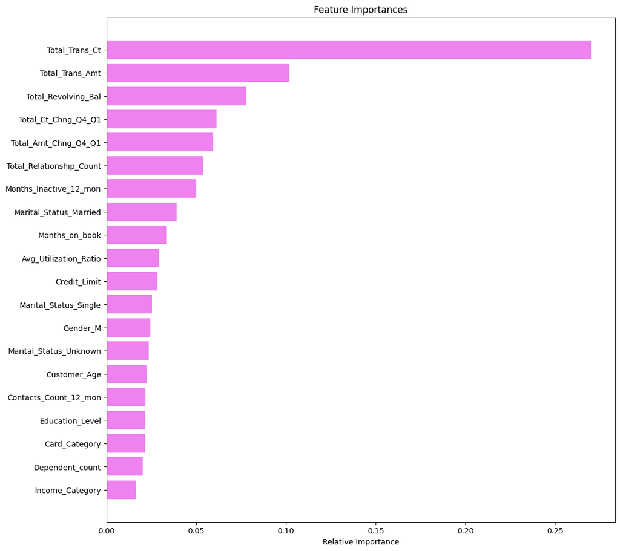

```python
feature_names = X_train.columns
importances = xgb_under_tuned.feature_importances_
indices = np.argsort(importances)

plt.figure(figsize=(12, 12))
plt.title("Feature Importances")
plt.barh(range(len(indices)), importances[indices], color="violet", align="center")
plt.yticks(range(len(indices)), [feature_names[i] for i in indices])
plt.xlabel("Relative Importance")
plt.show()
```

#### Observation

- We observe that Total_Trans_CT, Total_Trans_Amt and Total_Revolving_Bal are three most improtant features for making predictions.

# Business Insights and Conclusions

- From our data analysis we observed that customers who decided to close their accounts having less number of transactions. It is worth particularly looking at why customers are reducing transactions. Are there competitors who are offering better deal e.g. cashback, balance transfer etc
- We also noticed customers who decided to close thier accounts had reduced avg. transaction amounts over the last 12 month. This could be due to the affordability of the particular credit card or better deal available with competitors.
- Our analysis shows 25% customers who attrited have revolving balance 0. This behaviour could be due to high interest charges which eventually might lead the customer to find a better deal with competitors.
- The attrition rate is higher among female customers, it is worth investigating what is the root cause of it. Are competitors offering better incentive for feamle customers e.g. discount in beauty products when purchased using their card.
- Our analysis shows that the bank has relatively small number of Gold and Platinum credit card holders and the attrition rate is high among those customers. Low adoption of high tier credit card and high attrition rate among those card holders indicate those cards are probably not meeting customers' expectation.
- The bank has large number of customers around 35% who are earning below 40k, and attrition rate among those customers is 17.1%. It is worth investigating why these demographic of customers tend to close their credit card account.
- Attrited customers made more contacts than those customers who didn't. Also our analysis showed customers who closed their credit card account are likely to have less number of products with the bank. Its worth investigating whether there is a link between overall customer satisfaction and customer attrition.
- We observed both existing and attrited customers are spending less and reducing number of transactions in Q4 compared to Q1. 75% attrited customers reduced their number of transactions by 30% in Q4. It is worth finding out whether the competitors are offering better incentive in Q4 that led these customers to switch. Bank could consider incentivise Q4 spending with offers if that helps to generate more revenue.